# Proyecto Final

## 1.4 Usar str() y head() para ver más detalles y ejemplos concretos

> str() nos permite ver la estructura interna de cada objeto (como tipos de datos y clases), mientras que head() muestra las primeras filas de cada tabla para tener una idea concreta del contenido.

```r
# cities
str(cities)
```

```
spc_tbl_ [5 × 2] (S3: spec_tbl_df/tbl_df/tbl/data.frame)
 $ id  : num [1:5] 1 2 3 4 5
 $ city: chr [1:5] "Tel Aviv" "Ramat Gan" "Ramat Hasharon" "Herzelia" ...
 - attr(*, "spec")=
  .. cols(
  ..   id = col_double(),
  ..   city = col_character()
  .. )
 - attr(*, "problems")=<externalptr>
```

```r
head(cities)
```

| id | city |
| --- | --- |
| 1 | Tel Aviv |
| 2 | Ramat Gan |
| 3 | Ramat Hasharon |
| 4 | Herzelia |
| 5 | Givatayim |

```r
# meal_types
str(meal_types)
```

```
spc_tbl_ [4 × 2] (S3: spec_tbl_df/tbl_df/tbl/data.frame)
 $ id       : num [1:4] 1 2 3 4
 $ meal_type: chr [1:4] "Vegan" "Cheese" "Beef" "Chicken"
 - attr(*, "spec")=
  .. cols(
  ..   id = col_double(),
  ..   meal_type = col_character()
  .. )
 - attr(*, "problems")=<externalptr>
```

```r
head(meal_types)
```

| id | meal_type |
| --- | --- |
| 1 | Vegan |
| 2 | Cheese |
| 3 | Beef |
| 4 | Chicken |

```r
# meals
str(meals)
```

```
spc_tbl_ [350 × 7] (S3: spec_tbl_df/tbl_df/tbl/data.frame)
 $ id           : num [1:350] 1 2 3 4 5 6 7 8 9 10 ...
 $ restaurant_id: num [1:350] 1 1 1 1 1 1 1 1 1 1 ...
 $ serve_type_id: num [1:350] 1 2 3 3 3 3 3 2 2 1 ...
 $ meal_type_id : num [1:350] 2 4 1 2 2 2 2 1 2 3 ...
 $ hot_cold     : chr [1:350] "Cold" "Hot" "Cold" "Hot" ...
 $ meal_name    : chr [1:350] "Meal 1" "Meal 2" "Meal 3" "Meal 4" ...
 $ price        : num [1:350] 43.2 29.2 37.3 52.4 27.8 ...
 - attr(*, "spec")=
  .. cols(
  ..   id = col_double(),
  ..   restaurant_id = col_double(),
  ..   serve_type_id = col_double(),
  ..   meal_type_id = col_double(),
  ..   hot_cold = col_character(),
  ..   meal_name = col_character(),
  ..   price = col_double()
  .. )
 - attr(*, "problems")=<externalptr>
```

```r
head(meals)
```

| id | restaurant_id | serve_type_id | meal_type_id | hot_cold | meal_name | price |
| --- | --- | --- | --- | --- | --- | --- |
| 1 | 1 | 1 | 2 | Cold | Meal 1 | 43.22 |
| 2 | 1 | 2 | 4 | Hot | Meal 2 | 29.22 |
| 3 | 1 | 3 | 1 | Cold | Meal 3 | 37.34 |
| 4 | 1 | 3 | 2 | Hot | Meal 4 | 52.41 |
| 5 | 1 | 3 | 2 | Cold | Meal 5 | 27.75 |
| 6 | 1 | 3 | 2 | Cold | Meal 6 | 32.08 |

```r
# members
str(members)
```

```
spc_tbl_ [200 × 7] (S3: spec_tbl_df/tbl_df/tbl/data.frame)
 $ id            : num [1:200] 1 2 3 4 5 6 7 8 9 10 ...
 $ first_name    : chr [1:200] "Ollie" "Landon" "Jia" "Valentina" ...
 $ surname       : chr [1:200] "Kinney" "Bishop" "Delarosa" "Ratcliffe" ...
 $ sex           : chr [1:200] "M" "F" "M" "F" ...
 $ email         : chr [1:200] "Ol.Kinney@walla.co.il" "La.Bi@gmail.com" "Jia.De@gmail.com" "Va.Ratcliffe@gmail.com" ...
 $ city_id       : num [1:200] 4 4 4 4 3 3 4 5 2 5 ...
 $ monthly_budget: num [1:200] 1000 500 500 600 500 600 500 600 500 600 ...
 - attr(*, "spec")=
  .. cols(
  ..   id = col_double(),
  ..   first_name = col_character(),
  ..   surname = col_character(),
  ..   sex = col_character(),
  ..   email = col_character(),
  ..   city_id = col_double(),
  ..   monthly_budget = col_double()
  .. )
 - attr(*, "problems")=<externalptr>
```

```r
head(members)
```

| id | first_name | surname | sex | email | city_id | monthly_budget |
| --- | --- | --- | --- | --- | --- | --- |
| 1 | Ollie | Kinney | M | Ol.Kinney@walla.co.il | 4 | 1000 |
| 2 | Landon | Bishop | F | La.Bi@gmail.com | 4 | 500 |
| 3 | Jia | Delarosa | M | Jia.De@gmail.com | 4 | 500 |
| 4 | Valentina | Ratcliffe | F | Va.Ratcliffe@gmail.com | 4 | 600 |
| 5 | Stacie | Patel | F | St.Patel@hotmail.com | 3 | 500 |
| 6 | Fallon | Case | M | Fa.Case@walla.co.il | 3 | 600 |

```r
# monthly_member_totals
str(monthly_member_totals)
```

```
spc_tbl_ [1,200 × 14] (S3: spec_tbl_df/tbl_df/tbl/data.frame)
 $ member_id     : num [1:1200] 47 126 68 193 53 115 192 19 176 130 ...
 $ first_name    : chr [1:1200] "Joyce" "Macey" "Aydin" "Mira" ...
 $ surname       : chr [1:1200] "Newton" "Almond" "Hirst" "Kent" ...
 $ sex           : chr [1:1200] "F" "M" "M" "M" ...
 $ email         : chr [1:1200] "Joyce.Ne@gmail.com" "Macey.Almond@yahoo.com" "Aydin.Hirst@hotmail.com" "Mi.Kent@walla.co.il" ...
 $ city          : chr [1:1200] "Herzelia" "Tel Aviv" "Tel Aviv" "Tel Aviv" ...
 $ year          : num [1:1200] 2020 2020 2020 2020 2020 2020 2020 2020 2020 2020 ...
 $ month         : num [1:1200] 1 1 1 1 1 1 1 1 1 1 ...
 $ order_count   : num [1:1200] 17 30 24 24 23 25 21 20 21 20 ...
 $ meals_count   : num [1:1200] 37 64 52 54 50 62 46 36 51 52 ...
 $ monthly_budget: num [1:1200] 1836 2677 2287 2548 2457 ...
 $ total_expense : num [1:1200] 500 1000 1000 500 1000 600 1000 1000 600 1000 ...
 $ balance       : num [1:1200] -1336 -1677 -1287 -2048 -1457 ...
 $ commission    : num [1:1200] 136 215 165 194 194 ...
 - attr(*, "spec")=
  .. cols(
  ..   member_id = col_double(),
  ..   first_name = col_character(),
  ..   surname = col_character(),
  ..   sex = col_character(),
  ..   email = col_character(),
  ..   city = col_character(),
  ..   year = col_double(),
  ..   month = col_double(),
  ..   order_count = col_double(),
  ..   meals_count = col_double(),
  ..   monthly_budget = col_double(),
  ..   total_expense = col_double(),
  ..   balance = col_double(),
  ..   commission = col_double()
  .. )
 - attr(*, "problems")=<externalptr>
```

```r
head(monthly_member_totals)
```

| member_id | first_name | surname | sex | email | city | year | month | order_count | meals_count | monthly_budget | total_expense | balance | commission |
| --- | --- | --- | --- | --- | --- | --- | --- | --- | --- | --- | --- | --- | --- |
| 47 | Joyce | Newton | F | Joyce.Ne@gmail.com | Herzelia | 2020 | 1 | 17 | 37 | 1836.15 | 500 | -1336.15 | 136.2795 |
| 126 | Macey | Almond | M | Macey.Almond@yahoo.com | Tel Aviv | 2020 | 1 | 30 | 64 | 2676.98 | 1000 | -1676.98 | 214.9850 |
| 68 | Aydin | Hirst | M | Aydin.Hirst@hotmail.com | Tel Aviv | 2020 | 1 | 24 | 52 | 2286.53 | 1000 | -1286.53 | 164.9385 |
| 193 | Mira | Kent | M | Mi.Kent@walla.co.il | Tel Aviv | 2020 | 1 | 24 | 54 | 2547.62 | 500 | -2047.62 | 193.5912 |
| 53 | Lilly-Ann | Frey | F | Li.Fr@hotmail.com | Tel Aviv | 2020 | 1 | 23 | 50 | 2456.64 | 1000 | -1456.64 | 193.9765 |
| 115 | Rami | Sexton | M | Rami.Sexton@hotmail.com | Ramat Gan | 2020 | 1 | 25 | 62 | 2760.23 | 600 | -2160.23 | 211.0977 |

```r
# order_details
str(order_details)
```

```
spc_tbl_ [70,577 × 3] (S3: spec_tbl_df/tbl_df/tbl/data.frame)
 $ id      : num [1:70577] 1 2 3 4 5 6 7 8 9 10 ...
 $ order_id: num [1:70577] 3 5 5 5 5 6 6 6 7 7 ...
 $ meal_id : num [1:70577] 176 349 348 344 348 290 291 293 252 249 ...
 - attr(*, "spec")=
  .. cols(
  ..   id = col_double(),
  ..   order_id = col_double(),
  ..   meal_id = col_double()
  .. )
 - attr(*, "problems")=<externalptr>
```

```r
head(order_details)
```

| id | order_id | meal_id |
| --- | --- | --- |
| 1 | 3 | 176 |
| 2 | 5 | 349 |
| 3 | 5 | 348 |
| 4 | 5 | 344 |
| 5 | 5 | 348 |
| 6 | 6 | 290 |

```r
# orders
str(orders)
```

```
spc_tbl_ [36,000 × 6] (S3: spec_tbl_df/tbl_df/tbl/data.frame)
 $ id           : num [1:36000] 1 2 3 4 5 6 7 8 9 10 ...
 $ date         : Date[1:36000], format: "2020-01-01" "2020-01-01" ...
 $ hour         : 'hms' num [1:36000] 11:00:00 11:08:00 11:10:00 11:13:00 ...
  ..- attr(*, "units")= chr "secs"
 $ member_id    : num [1:36000] 25 122 62 171 152 166 25 95 40 149 ...
 $ restaurant_id: num [1:36000] 6 4 16 9 30 25 21 1 30 19 ...
 $ total_order  : num [1:36000] 0 0 39 0 153 ...
 - attr(*, "spec")=
  .. cols(
  ..   id = col_double(),
  ..   date = col_date(format = ""),
  ..   hour = col_time(format = ""),
  ..   member_id = col_double(),
  ..   restaurant_id = col_double(),
  ..   total_order = col_double()
  .. )
 - attr(*, "problems")=<externalptr>
```

```r
head(orders)
```

| id | date | hour | member_id | restaurant_id | total_order |
| --- | --- | --- | --- | --- | --- |
| 1 | 2020-01-01 | 11:00:00 | 25 | 6 | 0.00 |
| 2 | 2020-01-01 | 11:08:00 | 122 | 4 | 0.00 |
| 3 | 2020-01-01 | 11:10:00 | 62 | 16 | 39.00 |
| 4 | 2020-01-01 | 11:13:00 | 171 | 9 | 0.00 |
| 5 | 2020-01-01 | 11:13:00 | 152 | 30 | 153.00 |
| 6 | 2020-01-01 | 11:13:00 | 166 | 25 | 120.33 |

```r
# restaurant_types
str(restaurant_types)
```

```
spc_tbl_ [5 × 2] (S3: spec_tbl_df/tbl_df/tbl/data.frame)
 $ id             : num [1:5] 1 2 3 4 5
 $ restaurant_type: chr [1:5] "Fast Food" "Asian" "Italian" "Homemade" ...
 - attr(*, "spec")=
  .. cols(
  ..   id = col_double(),
  ..   restaurant_type = col_character()
  .. )
 - attr(*, "problems")=<externalptr>
```

```r
head(restaurant_types)
```

| id | restaurant_type |
| --- | --- |
| 1 | Fast Food |
| 2 | Asian |
| 3 | Italian |
| 4 | Homemade |
| 5 | Indian |

```r
# restaurants
str(restaurants)
```

```
spc_tbl_ [30 × 5] (S3: spec_tbl_df/tbl_df/tbl/data.frame)
 $ id                : num [1:30] 1 2 3 4 5 6 7 8 9 10 ...
 $ restaurant_name   : chr [1:30] "Restaurant 1" "Restaurant 2" "Restaurant 3" "Restaurant 4" ...
 $ restaurant_type_id: num [1:30] 3 5 2 4 5 1 1 2 1 4 ...
 $ income_persentage : num [1:30] 0.075 0.1 0.075 0.1 0.05 0.05 0.1 0.075 0.075 0.1 ...
 $ city_id           : num [1:30] 3 3 4 4 2 2 4 5 4 2 ...
 - attr(*, "spec")=
  .. cols(
  ..   id = col_double(),
  ..   restaurant_name = col_character(),
  ..   restaurant_type_id = col_double(),
  ..   income_persentage = col_double(),
  ..   city_id = col_double()
  .. )
 - attr(*, "problems")=<externalptr>
```

```r
head(restaurants)
```

| id | restaurant_name | restaurant_type_id | income_persentage | city_id |
| --- | --- | --- | --- | --- |
| 1 | Restaurant 1 | 3 | 0.075 | 3 |
| 2 | Restaurant 2 | 5 | 0.100 | 3 |
| 3 | Restaurant 3 | 2 | 0.075 | 4 |
| 4 | Restaurant 4 | 4 | 0.100 | 4 |
| 5 | Restaurant 5 | 5 | 0.050 | 2 |
| 6 | Restaurant 6 | 1 | 0.050 | 2 |

```r
# serve_types
str(serve_types)
```

```
spc_tbl_ [3 × 2] (S3: spec_tbl_df/tbl_df/tbl/data.frame)
 $ id        : num [1:3] 1 2 3
 $ serve_type: chr [1:3] "Starter" "Main" "Desert"
 - attr(*, "spec")=
  .. cols(
  ..   id = col_double(),
  ..   serve_type = col_character()
  .. )
 - attr(*, "problems")=<externalptr>
```

```r
head(serve_types)
```

| id | serve_type |
| --- | --- |
| 1 | Starter |
| 2 | Main |
| 3 | Desert |

# 2 Transformando los datos

## 2.1 Convertir la columna sex en factor en members y renombrar niveles

> En esta sección trabajamos con el dataset de miembros (members) para transformar la columna sex en un factor con niveles más legibles: “Femenino” y “Masculino”.

```r
# Convert 'sex' to factor and rename levels
members <- members %>%
  mutate(sex = factor(sex, levels = c("F", "M"), labels = c("Femenino", "Masculino")))
```

## 2.2 Transformar hot_cold en factor en meals y aplicar orden (“cold” < “hot”)

> Aquí usamos la columna hot_cold del dataset meals, que indica si la comida es caliente o fría, y la convertimos en un factor ordenado.

```r
# Convert 'hot_cold' to ordered factor with "cold" < "hot"
meals <- meals %>%
  mutate(hot_cold = factor(hot_cold, levels = c("cold", "hot"), ordered = TRUE))

# Validate order comparison
levels(meals$hot_cold)  # This returns TRUE if the order was applied correctly
```

```
[1] "cold" "hot"
```

```
cold
hot
```

## 2.3 Transformar columnas en monthly_member_totals y crear nueva columna

> En este paso, trabajamos con monthly_member_totals. Convertimos sex y month a factores con etiquetas descriptivas, y luego creamos una nueva columna que calcula la proporción de órdenes respecto al número de comidas.

```r
# Transform 'sex' and 'month' to labeled factors and create 'order_meal_ratio'
monthly_member_totals <- monthly_member_totals %>%
  mutate(
    sex = factor(sex, levels = c("F", "M"), labels = c("Femenino", "Masculino")),
    month = factor(month, levels = c("1", "2", "3", "4", "5"),
                          labels = c("Enero", "Febrero", "Marzo", "Abril", "Mayo")),
    order_meal_ratio = order_count / meals_count
  )
```

## 2.4 Imprimir la variable modificada con la nueva columna

> Finalmente imprimimos el dataset transformado para verificar que los cambios se hayan aplicado correctamente.

```r
# Print transformed data with new column
glimpse(monthly_member_totals)
```

```
Rows: 1,200
Columns: 15
$ member_id        <dbl> 47, 126, 68, 193, 53, 115, 192, 19, 176, 130, 195, 19…
$ first_name       <chr> "Joyce", "Macey", "Aydin", "Mira", "Lilly-Ann", "Rami…
$ surname          <chr> "Newton", "Almond", "Hirst", "Kent", "Frey", "Sexton"…
$ sex              <fct> Femenino, Masculino, Masculino, Masculino, Femenino, …
$ email            <chr> "Joyce.Ne@gmail.com", "Macey.Almond@yahoo.com", "Aydi…
$ city             <chr> "Herzelia", "Tel Aviv", "Tel Aviv", "Tel Aviv", "Tel …
$ year             <dbl> 2020, 2020, 2020, 2020, 2020, 2020, 2020, 2020, 2020,…
$ month            <fct> Enero, Enero, Enero, Enero, Enero, Enero, Enero, Ener…
$ order_count      <dbl> 17, 30, 24, 24, 23, 25, 21, 20, 21, 20, 25, 29, 22, 2…
$ meals_count      <dbl> 37, 64, 52, 54, 50, 62, 46, 36, 51, 52, 56, 65, 38, 5…
$ monthly_budget   <dbl> 1836.15, 2676.98, 2286.53, 2547.62, 2456.64, 2760.23,…
$ total_expense    <dbl> 500, 1000, 1000, 500, 1000, 600, 1000, 1000, 600, 100…
$ balance          <dbl> -1336.15, -1676.98, -1286.53, -2047.62, -1456.64, -21…
$ commission       <dbl> 136.2795, 214.9850, 164.9385, 193.5912, 193.9765, 211…
$ order_meal_ratio <dbl> 0.4594595, 0.4687500, 0.4615385, 0.4444444, 0.4600000…
```

```r
head(monthly_member_totals)
```

| member_id | first_name | surname | sex | email | city | year | month | order_count | meals_count | monthly_budget | total_expense | balance | commission | order_meal_ratio |
| --- | --- | --- | --- | --- | --- | --- | --- | --- | --- | --- | --- | --- | --- | --- |
| 47 | Joyce | Newton | Femenino | Joyce.Ne@gmail.com | Herzelia | 2020 | Enero | 17 | 37 | 1836.15 | 500 | -1336.15 | 136.2795 | 0.4594595 |
| 126 | Macey | Almond | Masculino | Macey.Almond@yahoo.com | Tel Aviv | 2020 | Enero | 30 | 64 | 2676.98 | 1000 | -1676.98 | 214.9850 | 0.4687500 |
| 68 | Aydin | Hirst | Masculino | Aydin.Hirst@hotmail.com | Tel Aviv | 2020 | Enero | 24 | 52 | 2286.53 | 1000 | -1286.53 | 164.9385 | 0.4615385 |
| 193 | Mira | Kent | Masculino | Mi.Kent@walla.co.il | Tel Aviv | 2020 | Enero | 24 | 54 | 2547.62 | 500 | -2047.62 | 193.5912 | 0.4444444 |
| 53 | Lilly-Ann | Frey | Femenino | Li.Fr@hotmail.com | Tel Aviv | 2020 | Enero | 23 | 50 | 2456.64 | 1000 | -1456.64 | 193.9765 | 0.4600000 |
| 115 | Rami | Sexton | Masculino | Rami.Sexton@hotmail.com | Ramat Gan | 2020 | Enero | 25 | 62 | 2760.23 | 600 | -2160.23 | 211.0977 | 0.4032258 |

```r
print(monthly_member_totals)
```

```
# A tibble: 1,200 × 15
   member_id first_name surname  sex       email   city   year month order_count
       <dbl> <chr>      <chr>    <fct>     <chr>   <chr> <dbl> <fct>       <dbl>
 1        47 Joyce      Newton   Femenino  Joyce.… Herz…  2020 Enero          17
 2       126 Macey      Almond   Masculino Macey.… Tel …  2020 Enero          30
 3        68 Aydin      Hirst    Masculino Aydin.… Tel …  2020 Enero          24
 4       193 Mira       Kent     Masculino Mi.Ken… Tel …  2020 Enero          24
 5        53 Lilly-Ann  Frey     Femenino  Li.Fr@… Tel …  2020 Enero          23
 6       115 Rami       Sexton   Masculino Rami.S… Rama…  2020 Enero          25
 7       192 Amrit      Haworth  Masculino Am.Ha@… Giva…  2020 Enero          21
 8        19 Nico       Hastings Masculino Ni.Has… Giva…  2020 Enero          20
 9       176 Amman      Zavala   Femenino  Am.Zav… Giva…  2020 Enero          21
10       130 Haleemah   Davidson Femenino  Haleem… Tel …  2020 Enero          20
# ℹ 1,190 more rows
# ℹ 6 more variables: meals_count <dbl>, monthly_budget <dbl>,
#   total_expense <dbl>, balance <dbl>, commission <dbl>,
#   order_meal_ratio <dbl>
```

# 3 Comportamiento de los datos

**Evaluando tendencias lineales**

## 3.1 Graficar la proporción order_count / meals_count como línea

> Creamos una gráfica lineal usando ggplot para visualizar la columna order_meal_ratio a través de los meses.

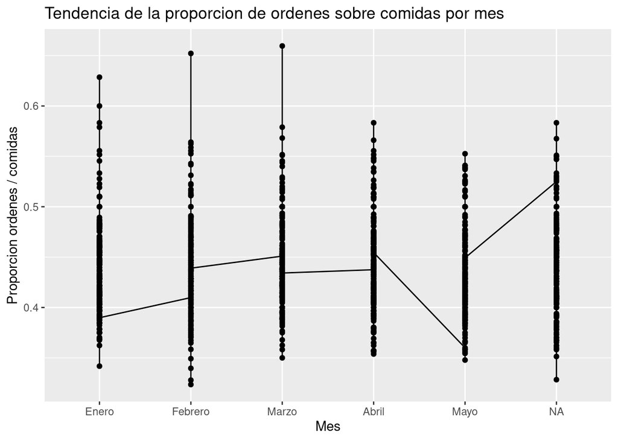

```r
# Line plot: order_meal_ratio vs. month without color aesthetics
ggplot(monthly_member_totals, aes(x = month, y = order_meal_ratio, group = 1)) +
  geom_line() +
  geom_point() +
  labs(
    title = "Tendencia de la proporcion de ordenes sobre comidas por mes",
    x = "Mes",
    y = "Proporcion ordenes / comidas"
  )
```

## 3.2 Usar color en la variable month para diferenciar en la gráfica

> Ahora aplicamos color a la variable month para que se diferencien los puntos y líneas en la visualización.

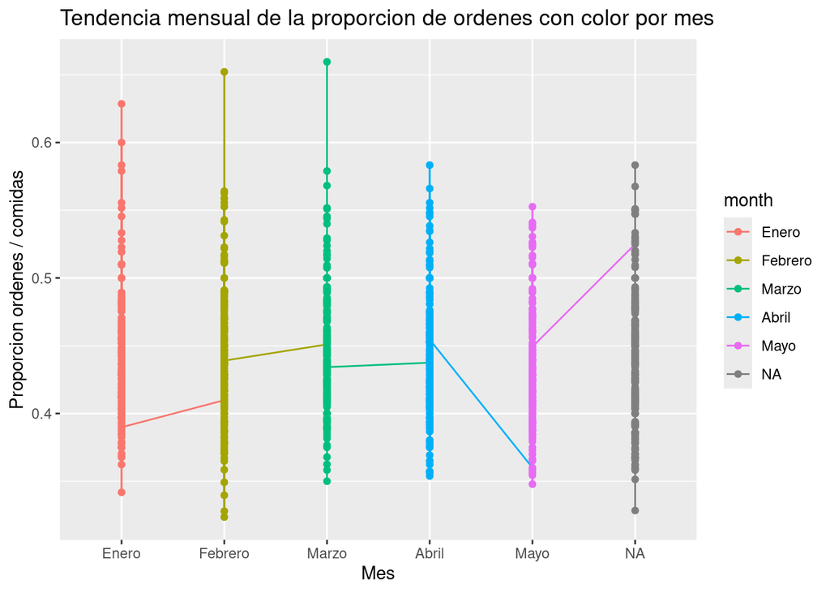

```r
# Line plot with month as color aesthetic
ggplot(monthly_member_totals, aes(x = month, y = order_meal_ratio, color = month, group = 1)) +
  geom_line() +
  geom_point() +
  labs(
    title = "Tendencia mensual de la proporcion de ordenes con color por mes",
    x = "Mes",
    y = "Proporcion ordenes / comidas"
  )
```

**Relación, selección y ordenamiento de datos**

## 3.3 Identificar los archivos a unir

> Se trabajará con los siguientes archivos:
- cities.csv
- members.csv
- orders.csv
- restaurants.csv

## 3.4 Usar inner_join() para construir las relaciones correspondientes

> Se combinan los datasets orders, members, cities (dos veces) y restaurants. Esto permite acceder tanto a la ciudad del cliente como a la del restaurante.

```r
# Join orders with members, cities, and restaurants (including restaurant city)
member_orders_joined <- orders %>%
  inner_join(members, by = c("member_id" = "id"), suffix = c(".order", ".member")) %>%
  inner_join(cities, by = c("city_id" = "id"), suffix = c(".member", ".city")) %>%
  inner_join(restaurants, by = c("restaurant_id" = "id"), suffix = c(".member", ".restaurant")) %>%
  inner_join(cities, by = c("city_id.restaurant" = "id"), suffix = c(".member", ".restaurant"))
```

## 3.5 Usar select() para mostrar los campos especificados

> Seleccionamos los campos solicitados: datos personales, ciudad del miembro, fecha, hora y datos del restaurante.

```r
# Select required fields from the joined data
member_orders_selected <- member_orders_joined %>%
  select(
    first_name,
    surname,
    sex,
    email,
    city_member = city.member,
    date,
    hour,
    total_order,
    restaurant_name,
    city_restaurant = city.restaurant
  )
```

## 3.6 Ordenar ascendentemente por total_order

```r
# Sort the selected data by total_order in ascending order
member_orders_sorted <- member_orders_selected %>%
  arrange(total_order)
```

## 3.7 Imprimir el resultado ordenado

```r
# Print the first few rows of the sorted and selected data
print(member_orders_sorted)
```

```
# A tibble: 36,000 × 10
   first_name surname   sex       email city_member date       hour  total_order
   <chr>      <chr>     <fct>     <chr> <chr>       <date>     <tim>       <dbl>
 1 Safwan     Flowers   Masculino Sa.F… Tel Aviv    2020-01-01 11:00           0
 2 Ellena     Castro    Femenino  El.C… Herzelia    2020-01-01 11:08           0
 3 Hanna      Shelton   Femenino  Hann… Givatayim   2020-01-01 11:13           0
 4 Mairead    Acevedo   Femenino  Ma.A… Herzelia    2020-01-01 11:19           0
 5 Princess   Timms     Femenino  Pr.T… Tel Aviv    2020-01-01 11:29           0
 6 Parker     Drake     Masculino Park… Ramat Hash… 2020-01-01 11:36           0
 7 Armaan     Weston    Masculino Ar.W… Tel Aviv    2020-01-01 11:37           0
 8 Terrence   Payne     Masculino Te.P… Tel Aviv    2020-01-01 11:51           0
 9 Emaan      Greenaway Masculino Emaa… Herzelia    2020-01-01 11:59           0
10 Luka       Holder    Femenino  Luka… Givatayim   2020-01-01 12:05           0
# ℹ 35,990 more rows
# ℹ 2 more variables: restaurant_name <chr>, city_restaurant <chr>
```

**Obteniendo el conteo por tipo de comida**

## 3.8 Identificar los archivos que se usarán para la relación

> Se trabajará con los siguientes archivos:
- meals.csv
- serve_types.csv
- meal_types.csv
- restaurants.csv
- cities.csv
- restaurant_types.csv

## 3.9 Usar inner_join() para construir las relaciones entre tablas

> Se crea una tabla unificada combinando la información de comidas, tipos de servicio, tipos de comida, restaurantes, tipo de restaurante y ciudad.

```r
# Join meals with serve_types, meal_types, restaurants, restaurant_types, and cities
meals_detailed_info <- meals %>%
  inner_join(serve_types, by = c("serve_type_id" = "id"), suffix = c(".meal", ".serve_type")) %>%
  inner_join(meal_types, by = c("meal_type_id" = "id"), suffix = c(".meal", ".meal_type")) %>%
  inner_join(restaurants, by = c("restaurant_id" = "id"), suffix = c(".meal", ".restaurant")) %>%
  inner_join(restaurant_types, by = c("restaurant_type_id" = "id"), suffix = c(".restaurant", ".restaurant_type")) %>%
  inner_join(cities, by = c("city_id" = "id"), suffix = c(".restaurant", ".city"))
```

## 3.10 Seleccionar los campos especificados

> Extraemos únicamente las columnas relevantes para el análisis del tipo de comida y restaurante.

```r
# Select specified fields from the joined data
meals_selected_fields <- meals_detailed_info %>%
  select(
    restaurant_name,
    city,
    restaurant_type,
    income_persentage,
    serve_type,
    meal_type,
    meal_name,
    price
  )
```

## 3.11 Usar count() para obtener el conteo por tipo de comida (meal_type)

```r
# Count the number of meals per meal_type
meal_type_count <- meals_selected_fields %>%
  count(meal_type)
```

## 3.12 Imprimir el conteo obtenido

```r
# Print the result of the count
print(meal_type_count)
```

```
# A tibble: 4 × 2
  meal_type     n
  <chr>     <int>
1 Beef         51
2 Cheese      139
3 Chicken      52
4 Vegan       108
```

**Comportamiento de ingresos por ciudad**

## 3.13 Agrupar por ciudad y calcular la suma de income_persentage

> Utilizamos la tabla meals_selected_fields (creada en el inciso 3.10) para agrupar por ciudad y sumar el porcentaje de ingresos de los restaurantes.

```r
# Group by city and summarize total income percentage
income_by_city <- meals_selected_fields %>%
  group_by(city) %>%
  summarize(sum_income_percentage = sum(income_persentage))
```

## 3.14 Imprimir el resultado de la agrupación

```r
# Print the summarized income by city
print(income_by_city)
```

```
# A tibble: 5 × 2
  city           sum_income_percentage
  <chr>                          <dbl>
1 Givatayim                       1.85
2 Herzelia                        8.65
3 Ramat Gan                       5.12
4 Ramat Hasharon                  6.08
5 Tel Aviv                        5.25
```

## 3.15 Crear gráfico de barras con ggplot sin color por ciudad

> Visualizamos los ingresos totales por ciudad en una gráfica de barras simple.

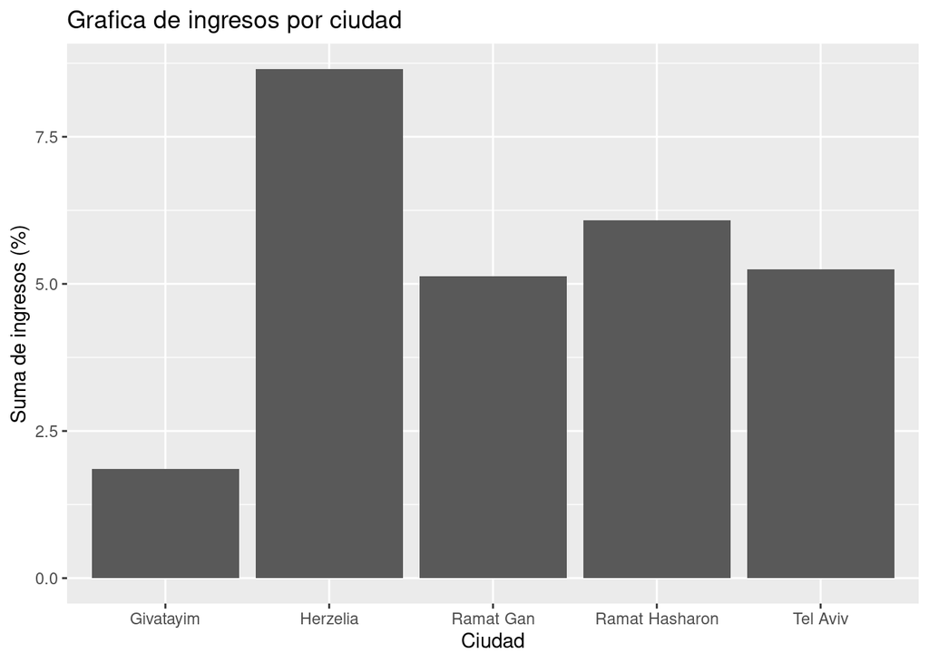

```r
# Bar chart of total income percentage per city (without color)
ggplot(income_by_city, aes(x = city, y = sum_income_percentage)) +
  geom_bar(stat = "identity") +
  labs(
    title = "Grafica de ingresos por ciudad",
    x = "Ciudad",
    y = "Suma de ingresos (%)"
  )
```

## 3.16 Agregar color a la variable city en la estética del gráfico

> Ahora aplicamos color a cada barra según la ciudad.

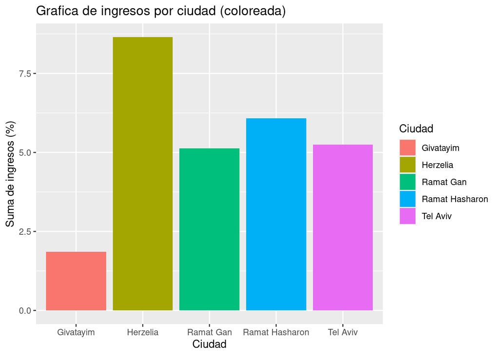

```r
# Bar chart with city-colored fill
ggplot(income_by_city, aes(x = city, y = sum_income_percentage, fill = city)) +
  geom_bar(stat = "identity") +
  labs(
    title = "Grafica de ingresos por ciudad (coloreada)",
    x = "Ciudad",
    y = "Suma de ingresos (%)",
    fill = "Ciudad"
  ) +
  scale_fill_discrete(name = "Ciudad")
```

Interpretación: La gráfica muestra cómo varía el ingreso generado por los restaurantes en distintas ciudades. Podemos observar que ciertas ciudades como “Herzelia” y “Ramat Hasharon”, concentran mayores porcentajes de ingreso, lo cual puede estar influenciado por la densidad de restaurantes, el poder adquisitivo de los clientes o las estrategias de los establecimientos en esa ciudad. Esta información es útil para decisiones de expansión o inversión.

**Conociendo la tendencia de consumo en un restaurante en particular**

## 3.17 Filtrar los datos con condiciones específicas

> Filtramos la tabla meals_selected_fields para quedarnos únicamente con:
- meal_type igual a “Vegan” o “Chicken”
- restaurant_name igual a “Restaurant 2”
- price mayor a 30

```r
# Filter meals by specific conditions
restaurant2_filtered_meals <- meals_selected_fields %>%
  filter(
    meal_type %in% c("Vegan", "Chicken"),
    restaurant_name == "Restaurant 2",
    price > 30
  )
```

## 3.18 Guardar el resultado filtrado en una nueva variable

> El resultado ya fue guardado en restaurant2_filtered_meals, por lo que este inciso ya está cubierto.

## 3.19 Crear gráfico de barras con serve_type en eje X y price en eje Y

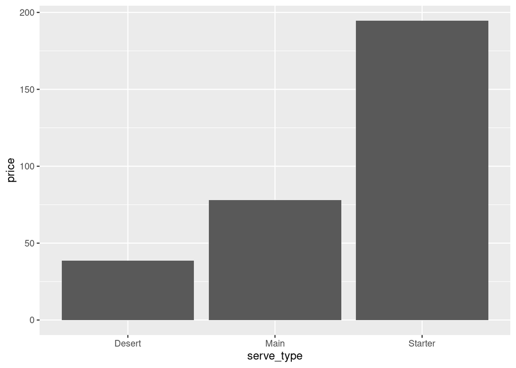

```r
# Bar chart for price per serve_type
ggplot(restaurant2_filtered_meals, aes(x = serve_type, y = price)) +
  geom_bar(stat = "identity")
```

## 3.20 Agregar título, subtítulo y etiquetas usando labs()

> Aplicamos etiquetas descriptivas al gráfico generado, usando labs().

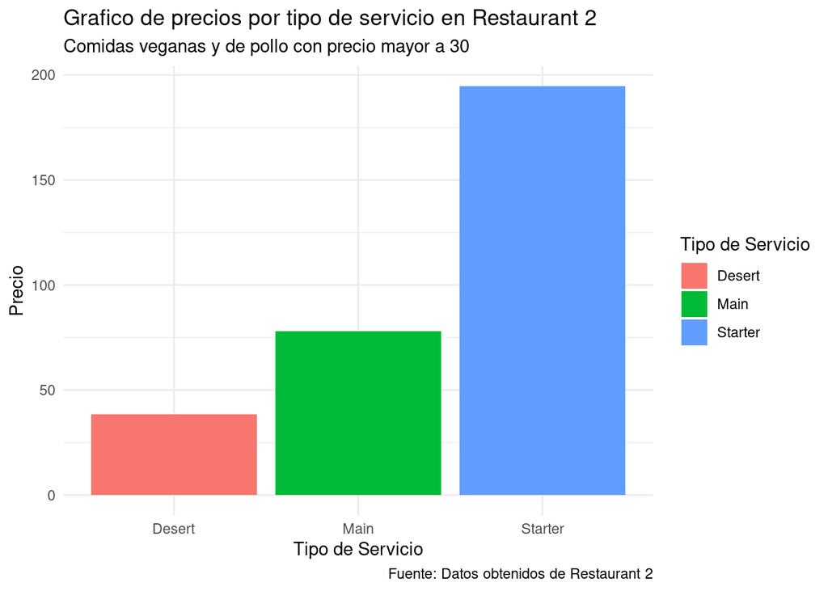

```r
# Add labels and style to the previous bar chart
ggplot(restaurant2_filtered_meals, aes(x = serve_type, y = price, fill = serve_type)) +
  geom_bar(stat = "identity") +
  labs(
    title = "Grafico de precios por tipo de servicio en Restaurant 2",
    subtitle = "Comidas veganas y de pollo con precio mayor a 30",
    x = "Tipo de Servicio",
    y = "Precio",
    caption = "Fuente: Datos obtenidos de Restaurant 2",
    fill = "Tipo de Servicio"
  ) + theme_minimal()
```

**Tendencias de comida por restaurante y ubicación (ciudad)**

## 3.21 Identificar archivos para la relación de tendencias por ciudad y restaurante

> Los archivos a utilizar seran:
- cities.csv
- restaurants.csv
- restaurant_types.csv
- orders.csv
- meals.csv
- serve_types.csv
- meal_types.csv
- order_details.csv

## 3.22 Construir las relaciones entre los datasets con inner_join()

> Unimos los datos para obtener una tabla que combine información de órdenes, comidas, tipos de comida y servicio, y ubicación del restaurante.

```r
# Join orders with all relevant datasets to analyze trends
trends_combined_data <- orders %>%
  inner_join(order_details, by = c("id" = "order_id"), suffix = c(".order", ".details")) %>%
  inner_join(meals, by = c("meal_id" = "id"), suffix = c(".order", ".meal")) %>%
  inner_join(serve_types, by = c("serve_type_id" = "id")) %>%
  inner_join(meal_types, by = c("meal_type_id" = "id")) %>%
  inner_join(restaurants, by = c("restaurant_id.meal" = "id")) %>%
  inner_join(cities, by = c("city_id" = "id")) %>%
  inner_join(restaurant_types, by = c("restaurant_type_id" = "id"))
```

## 3.23 Seleccionar los campos especificados para el análisis

> Nos quedamos con las columnas necesarias para visualizar tendencias por restaurante y ciudad.

```r
# Select specified fields from the joined data
trends_selected_fields <- trends_combined_data %>%
  select(
    restaurant_name,
    city,
    restaurant_type,
    income_persentage,
    serve_type,
    meal_type,
    meal_name,
    price,
    date,
    hour,
    total_order,
    order_detail_id = id.details
  )
```

## 3.24 Agrupar por city, restaurant_name y meal_name

```r
# Group by city, restaurant, and meal name
trends_grouped <- trends_selected_fields %>%
  group_by(city, restaurant_name, meal_name)
```

## 3.25 Sumarizar total_order y asignar etiqueta totals

```r
# Summarize total orders per group
trends_summarized <- trends_grouped %>%
  summarise(totals = sum(total_order), .groups = "drop")
```

## 3.26 Guardar el resultado y mostrarlo

```r
# Print summarized trends by restaurant and city
print(trends_summarized)
```

```
# A tibble: 350 × 4
   city      restaurant_name meal_name totals
   <chr>     <chr>           <chr>      <dbl>
 1 Givatayim Restaurant 22   Meal 253  27703.
 2 Givatayim Restaurant 22   Meal 254  26473.
 3 Givatayim Restaurant 22   Meal 255  27487.
 4 Givatayim Restaurant 22   Meal 256  25189.
 5 Givatayim Restaurant 22   Meal 257  23003.
 6 Givatayim Restaurant 22   Meal 258  29993.
 7 Givatayim Restaurant 22   Meal 259  26882.
 8 Givatayim Restaurant 22   Meal 260  24728.
 9 Givatayim Restaurant 22   Meal 261  36397.
10 Givatayim Restaurant 22   Meal 262  38579.
# ℹ 340 more rows
```

## 3.27 Crear gráfico de barras con restaurantes en eje X y totales en eje Y

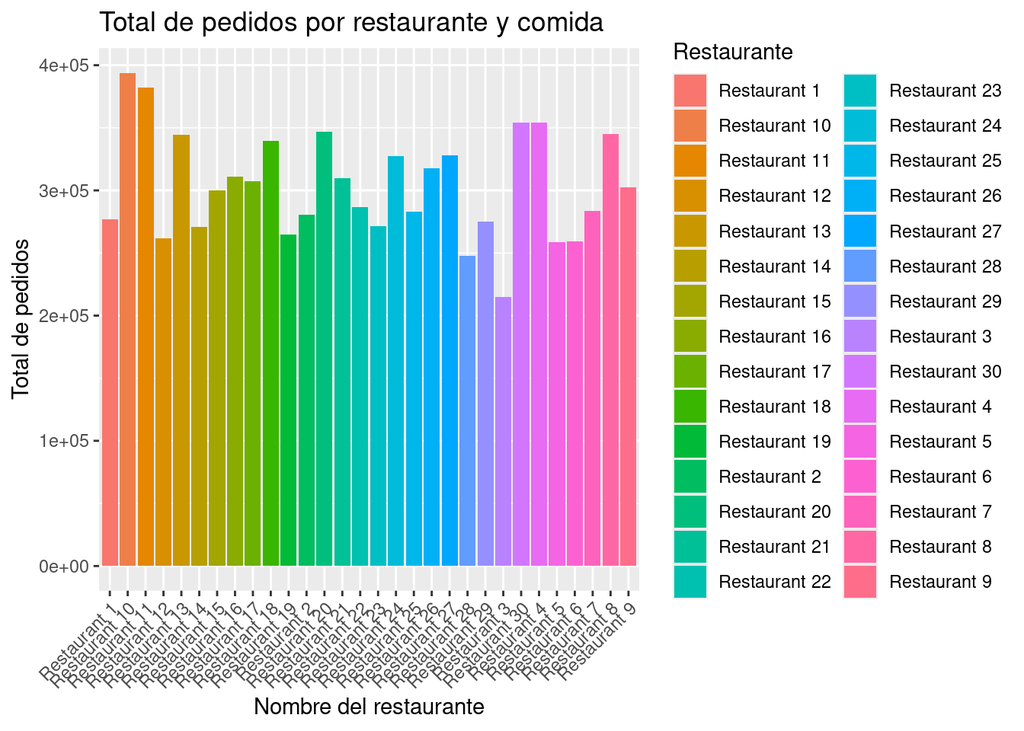

```r
# Bar chart: total orders per restaurant
trends_barplot <- ggplot(data = trends_summarized, aes(x = restaurant_name, y = totals, fill = restaurant_name)) +
  geom_bar(stat = "identity") +
  labs(
    title = "Total de pedidos por restaurante y comida",
    x = "Nombre del restaurante",
    y = "Total de pedidos",
    fill = "Restaurante"
  ) +
  theme(axis.text.x = element_text(angle = 45, hjust = 1))

trends_barplot
```

## 3.28 Aplicar faceting por ciudad para dividir el gráfico

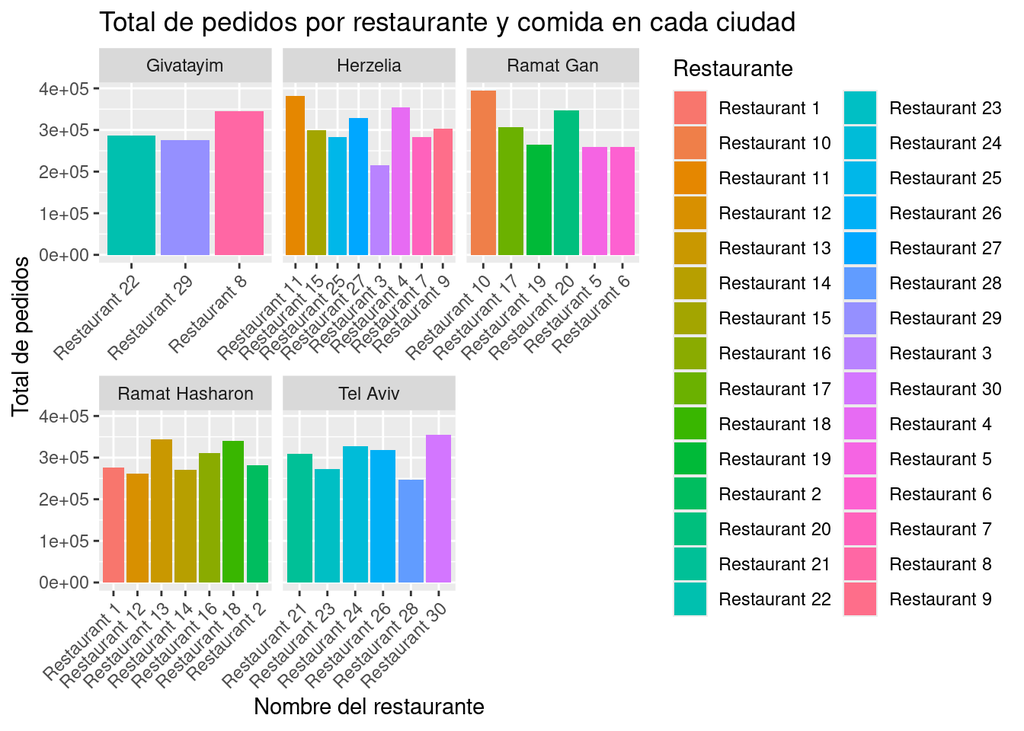

```r
# Add faceting by city
trends_barplot_city <- trends_barplot +
  facet_wrap(~city, scales = "free_x") +
  labs(title = "Total de pedidos por restaurante y comida en cada ciudad")
trends_barplot_city
```

**Análisis estadístico propio**

## 3.29 Realizar un análisis estadístico propio

> Vamos a analizar si hay alguna diferencia en la distribución del gasto mensual (total_expense) entre hombres y mujeres, usando el dataset monthly_member_totals. Agruparemos por sex y visualizaremos la media y la mediana del gasto mensual. Luego usaremos un boxplot para observar la variabilidad.

```r
# Group by sex and summarize average and median total expense
expense_by_sex <- monthly_member_totals %>%
  group_by(sex) %>%
  summarise(
    promedio_gasto = mean(total_expense, na.rm = TRUE),
    mediana_gasto = median(total_expense, na.rm = TRUE),
    conteo = n()
  )

# Print summary table
print(expense_by_sex)
```

```
# A tibble: 2 × 4
  sex       promedio_gasto mediana_gasto conteo
  <fct>              <dbl>         <dbl>  <int>
1 Femenino             706           600    600
2 Masculino            707           600    600
```

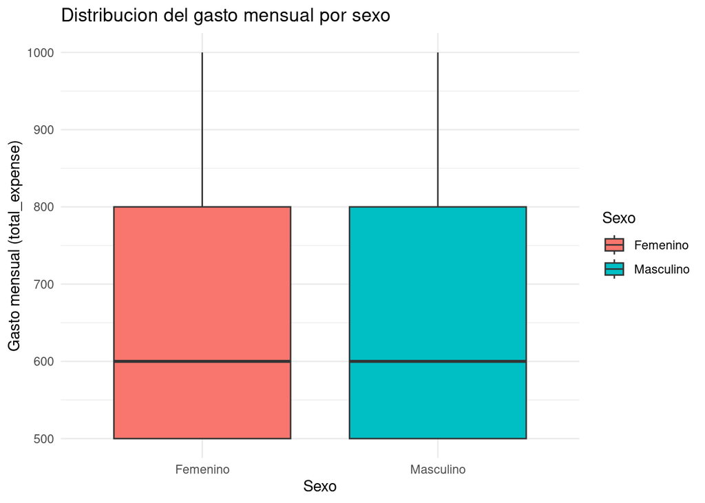

```r
# Boxplot to visualize the distribution of total_expense by sex
ggplot(monthly_member_totals, aes(x = sex, y = total_expense, fill = sex)) +
  geom_boxplot() +
  labs(
    title = "Distribucion del gasto mensual por sexo",
    x = "Sexo",
    y = "Gasto mensual (total_expense)",
    fill = "Sexo",
  ) +
  theme_minimal()
```

Interpretación: Este boxplot permite observar cómo varía el gasto mensual (total_expense) entre hombres y mujeres afiliados. El gráfico muestra la mediana, los cuartiles y los valores atípicos para cada grupo. Este tipo de análisis es fundamental para ajustar estrategias de precios, promociones o personalización de servicios en función del perfil del cliente.

### 3.29.1 Segundo Análisis estadístico propio (Amplio)

> Vamos a analizar el gasto total (total_order) por tipo de comida (meal_type) en cada ciudad. Este análisis integra:

> > Un análisis que muestre cuánto dinero se ha gastado en cada tipo de comida, por ciudad, integrando todas las tablas relevantes. Pero esta vez lo hacemos de una forma más estructurada y profesional, usando nombres de columnas con prefijos (como orders.date o meals.price), para que sea súper claro de qué tabla viene cada dato.
- Múltiples inner_join() y select() para crear una base consolidada y filtrar.
- group_by() y summarise() para agregar datos.
- arrange() para ordenarlos.
- Un gráfico con ggplot2 completo: título, subtítulo, leyenda, etiquetas, facet_wrap().
- Función renombra todas las columnas de un dataframe agregándoles un prefijo con el nombre de la tabla.

```r
# Función para prefijar columnas con el nombre de la tabla
prefix_columns <- function(df, table_name) {
  names(df) <- paste0(table_name, ".", names(df))
  return(df)
}

# Cargar y renombrar antes del join
orders_prefixed <- prefix_columns(orders, "orders")
order_details_prefixed <- prefix_columns(order_details, "order_details")
meals_prefixed <- prefix_columns(meals, "meals")
restaurants_prefixed <- prefix_columns(restaurants, "restaurants")
meal_types_prefixed <- prefix_columns(meal_types, "meal_types")
cities_prefixed <- prefix_columns(cities, "cities")

# Hacer los join usando las columnas renombradas
meal_expense_analysis <- orders_prefixed %>%
  inner_join(order_details_prefixed, by = c("orders.id" = "order_details.order_id")) %>%
  inner_join(meals_prefixed, by = c("order_details.meal_id" = "meals.id")) %>%
  inner_join(restaurants_prefixed, by = c("orders.restaurant_id" = "restaurants.id")) %>%
  inner_join(meal_types_prefixed, by = c("meals.meal_type_id" = "meal_types.id")) %>%
  inner_join(cities_prefixed, by = c("restaurants.city_id" = "cities.id"))

meal_expense_analysis_selected <- meal_expense_analysis %>%
  select(
    orders.id,
    orders.date,
    orders.total_order,
    meals.meal_name,
    meals.price,
    restaurants.restaurant_name,
    meal_types.meal_type,
    cities.city
  )

head(meal_expense_analysis_selected)
```

| orders.id | orders.date | orders.total_order | meals.meal_name | meals.price | restaurants.restaurant_name | meal_types.meal_type | cities.city |
| --- | --- | --- | --- | --- | --- | --- | --- |
| 3 | 2020-01-01 | 39.00 | Meal 176 | 39.00 | Restaurant 16 | Cheese | Ramat Hasharon |
| 5 | 2020-01-01 | 153.00 | Meal 349 | 54.51 | Restaurant 30 | Vegan | Tel Aviv |
| 5 | 2020-01-01 | 153.00 | Meal 348 | 37.15 | Restaurant 30 | Vegan | Tel Aviv |
| 5 | 2020-01-01 | 153.00 | Meal 344 | 24.19 | Restaurant 30 | Vegan | Tel Aviv |
| 5 | 2020-01-01 | 153.00 | Meal 348 | 37.15 | Restaurant 30 | Vegan | Tel Aviv |
| 6 | 2020-01-01 | 120.33 | Meal 290 | 46.79 | Restaurant 25 | Cheese | Herzelia |

```r
# Group by city and meal_type, then summarize total_order
expense_by_meal_and_city <- meal_expense_analysis_selected %>%
  group_by(cities.city, meal_types.meal_type) %>%
  summarise(total_gastado = sum(orders.total_order, na.rm = TRUE), .groups = "drop") %>%
  arrange(desc(total_gastado))

print(expense_by_meal_and_city)
```

```
# A tibble: 20 × 3
   cities.city    meal_types.meal_type total_gastado
   <chr>          <chr>                        <dbl>
 1 Herzelia       Cheese                     943634.
 2 Ramat Hasharon Cheese                     801273.
 3 Tel Aviv       Cheese                     732573.
 4 Tel Aviv       Vegan                      725541.
 5 Ramat Gan      Cheese                     723165.
 6 Ramat Hasharon Vegan                      714982.
 7 Herzelia       Vegan                      687773.
 8 Herzelia       Chicken                    461960.
 9 Givatayim      Cheese                     431645.
10 Ramat Gan      Vegan                      396388.
11 Ramat Gan      Beef                       378415.
12 Herzelia       Beef                       354162.
13 Ramat Hasharon Chicken                    348666.
14 Ramat Gan      Chicken                    333589.
15 Tel Aviv       Beef                       220594.
16 Ramat Hasharon Beef                       220134.
17 Givatayim      Vegan                      201510.
18 Givatayim      Beef                       187669.
19 Tel Aviv       Chicken                    149498.
20 Givatayim      Chicken                     85926.
```

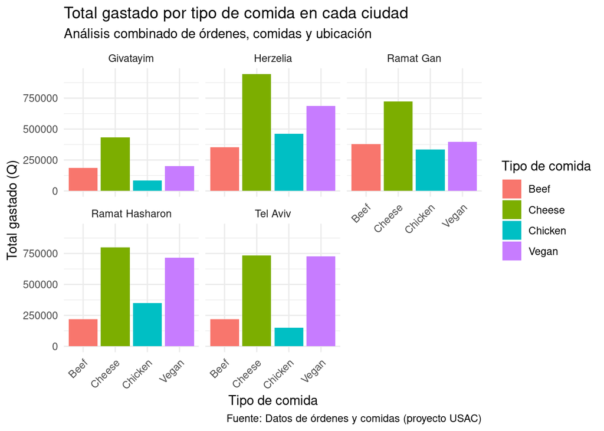

```r
# Bar chart with facets by city
ggplot(expense_by_meal_and_city, aes(x = meal_types.meal_type, y = total_gastado, fill = meal_types.meal_type)) +
  geom_bar(stat = "identity") +
  facet_wrap(~cities.city) +
  labs(
    title = "Total gastado por tipo de comida en cada ciudad",
    subtitle = "Análisis combinado de órdenes, comidas y ubicación",
    x = "Tipo de comida",
    y = "Total gastado (Q)",
    fill = "Tipo de comida",
    caption = "Fuente: Datos de órdenes y comidas (proyecto USAC)"
  ) +
  theme_minimal() +
  theme(axis.text.x = element_text(angle = 45, hjust = 1))
```

Interpretación: Este gráfico compara el total de dinero gastado en distintos tipos de comida (meal_type) en cada ciudad. Las facetas permiten visualizar los resultados por ciudad, mientras que el color diferencia cada categoría de comida.

- Ayuda a identificar preferencias locales: por ejemplo, si en una ciudad predomina el consumo de comida “Vegan” y en otra “Chicken”.
- Las diferencias de altura en las barras revelan cuáles son las categorías más rentables por zona, facilitando decisiones operativas específicas.

## 3.30 **Conclusiones Generales del Proyecto**

Este análisis ha permitido explorar de manera integral el comportamiento de clientes, órdenes y productos en una red de restaurantes, utilizando herramientas del ecosistema `tidyverse` en R.